# TelecomX_BR

## 📌 Importação de bibliotecas

```python
import pandas as pd
import numpy as np
```

```python
from scipy import stats
#from sklearn.preprocessing import MinMaxScaler, StandardScaler, Normalizer
```

```python
import seaborn as sns
import matplotlib.pyplot as plt
```

```python
import scripts.local_tools as lt
import scripts.telecomx_analysis as ta
```

```python
pd.set_option('display.max_columns', None)
```

## 📌 Extracão

### Extração dos dados

```python
path_json_data = 'https://raw.githubusercontent.com/jpierre06/challenge2-data-science/main/data/TelecomX_Data.json'
```

```python
df = ta.carregar_dados_telecomx_normalizado(path_json_data)
```

## 🔧 Transformação

### Tipo de dados

```python
df.info()
```

```
<class 'pandas.core.frame.DataFrame'>
RangeIndex: 7267 entries, 0 to 7266
Data columns (total 21 columns):
 #   Column                     Non-Null Count  Dtype
---  ------                     --------------  -----
 0   customerID                 7267 non-null   object
 1   Churn                      7267 non-null   object
 2   customer_gender            7267 non-null   object
 3   customer_SeniorCitizen     7267 non-null   int64
 4   customer_Partner           7267 non-null   object
 5   customer_Dependents        7267 non-null   object
 6   customer_tenure            7267 non-null   int64
 7   phone_PhoneService         7267 non-null   object
 8   phone_MultipleLines        7267 non-null   object
 9   internet_InternetService   7267 non-null   object
 10  internet_OnlineSecurity    7267 non-null   object
 11  internet_OnlineBackup      7267 non-null   object
 12  internet_DeviceProtection  7267 non-null   object
 13  internet_TechSupport       7267 non-null   object
 14  internet_StreamingTV       7267 non-null   object
 15  internet_StreamingMovies   7267 non-null   object
 16  account_Contract           7267 non-null   object
 17  account_PaperlessBilling   7267 non-null   object
 18  account_PaymentMethod      7267 non-null   object
 19  account_Charges_Monthly    7267 non-null   float64
 20  account_Charges_Total      7267 non-null   object
dtypes: float64(1), int64(2), object(18)
memory usage: 1.2+ MB
```

### Identificar colunas valores categóricos

```python
colunas_categoricas = ta.extrair_colunas_categoricas(df, 5)
```

```
Coluna: Churn. Quantidade de domínios: 3. Valores do domínios: ['' 'No' 'Yes']

Coluna: customer_gender. Quantidade de domínios: 2. Valores do domínios: ['Female' 'Male']

Coluna: customer_SeniorCitizen. Quantidade de domínios: 2. Valores do domínios: [0 1]

Coluna: customer_Partner. Quantidade de domínios: 2. Valores do domínios: ['No' 'Yes']

Coluna: customer_Dependents. Quantidade de domínios: 2. Valores do domínios: ['No' 'Yes']

Coluna: phone_PhoneService. Quantidade de domínios: 2. Valores do domínios: ['No' 'Yes']

Coluna: phone_MultipleLines. Quantidade de domínios: 3. Valores do domínios: ['No' 'No phone service' 'Yes']

Coluna: internet_InternetService. Quantidade de domínios: 3. Valores do domínios: ['DSL' 'Fiber optic' 'No']

Coluna: internet_OnlineSecurity. Quantidade de domínios: 3. Valores do domínios: ['No' 'No internet service' 'Yes']

Coluna: internet_OnlineBackup. Quantidade de domínios: 3. Valores do domínios: ['No' 'No internet service' 'Yes']

Coluna: internet_DeviceProtection. Quantidade de domínios: 3. Valores do domínios: ['No' 'No internet service' 'Yes']

Coluna: internet_TechSupport. Quantidade de domínios: 3. Valores do domínios: ['No' 'No internet service' 'Yes']

Coluna: internet_StreamingTV. Quantidade de domínios: 3. Valores do domínios: ['No' 'No internet service' 'Yes']

Coluna: internet_StreamingMovies. Quantidade de domínios: 3. Valores do domínios: ['No' 'No internet service' 'Yes']

Coluna: account_Contract. Quantidade de domínios: 3. Valores do domínios: ['Month-to-month' 'One year' 'Two year']

Coluna: account_PaperlessBilling. Quantidade de domínios: 2. Valores do domínios: ['No' 'Yes']

Coluna: account_PaymentMethod. Quantidade de domínios: 4. Valores do domínios: ['Bank transfer (automatic)' 'Credit card (automatic)' 'Electronic check'
 'Mailed check']
```

### Identificar colunas valores numericos

```python
colunas_numericas = ta.extrair_colunas_numericas(df, colunas_categoricas, ['customerID'])
```

```
['customer_tenure', 'account_Charges_Total', 'account_Charges_Monthly']
```

```python
for c in colunas_numericas:
    print(f'Coluna: {c}. Valores: {np.unique(df[c])}\n')
```

```
Coluna: customer_tenure. Valores: [ 0  1  2  3  4  5  6  7  8  9 10 11 12 13 14 15 16 17 18 19 20 21 22 23
 24 25 26 27 28 29 30 31 32 33 34 35 36 37 38 39 40 41 42 43 44 45 46 47
 48 49 50 51 52 53 54 55 56 57 58 59 60 61 62 63 64 65 66 67 68 69 70 71
 72]

Coluna: account_Charges_Total. Valores: [' ' '100.2' '100.25' ... '999.45' '999.8' '999.9']

Coluna: account_Charges_Monthly. Valores: [ 18.25  18.4   18.55 ... 118.6  118.65 118.75]
```

### Tratamento de valores inválidos

```python
# percentual de registros com valor de Churn inválidos
ta.perc_registros_churn_invalidados(df) *100
```

```
3.0824274115866244
```

```python
df = ta.tratar_valores_invalidados(df, limite_delecao=0.05, imprimir=True)
```

```
        Foram encontrados 224 registros inválidos na variável Churn
        que representa 3.08% do total de 7267 registros e está
        no limite da deleção que é de 5.00% e por isso foram deletados.


Registros inválidos antes do tratamento:

Valores inválidos na variável Churn: 224

Valores inválidos na variável account_Charges_Total: 11

Registros inválidos depois do tratamento:

Valores inválidos na variável Churn: 0

Valores inválidos na variável account_Charges_Total: 0

Clientes sem serviços de Telefone e Internet contratados: 0

Clientes com múltiplas linhas de Telefone sem serviço de Telefone contratado: 0
```

[output not shown]

### Tratamento de dados de colunas com valores binários

```python
df, colunas_valores_binarios = ta.tratar_colunas_valores_binarios(df)
```

```
Coluna: Churn. Quantidade de domínios: 2. Valores do domínios: [0 1]

Coluna: customer_SeniorCitizen. Quantidade de domínios: 2. Valores do domínios: [0 1]

Coluna: customer_Partner. Quantidade de domínios: 2. Valores do domínios: [0 1]

Coluna: customer_Dependents. Quantidade de domínios: 2. Valores do domínios: [0 1]

Coluna: phone_PhoneService. Quantidade de domínios: 2. Valores do domínios: [0 1]

Coluna: phone_MultipleLines. Quantidade de domínios: 2. Valores do domínios: [0 1]

Coluna: internet_InternetService. Quantidade de domínios: 2. Valores do domínios: [0 1]

Coluna: internet_OnlineSecurity. Quantidade de domínios: 2. Valores do domínios: [0 1]

Coluna: internet_OnlineBackup. Quantidade de domínios: 2. Valores do domínios: [0 1]

Coluna: internet_DeviceProtection. Quantidade de domínios: 2. Valores do domínios: [0 1]

Coluna: internet_TechSupport. Quantidade de domínios: 2. Valores do domínios: [0 1]

Coluna: internet_StreamingTV. Quantidade de domínios: 2. Valores do domínios: [0 1]

Coluna: internet_StreamingMovies. Quantidade de domínios: 2. Valores do domínios: [0 1]

Coluna: account_PaperlessBilling. Quantidade de domínios: 2. Valores do domínios: [0 1]
```

### Conversão de tipo de dados

```python
df = lt.convert_types(df, ['account_Charges_Total'], ['float'])
```

### Criação de colunas derivadas dos dados

```python
df = ta.criar_colunas_derivadas(df)
```

```python
colunas_valores_binarios = ta.identificar_colunas_valores_binarios(df)
```

```python
df.info()
```

```
<class 'pandas.core.frame.DataFrame'>
Index: 7043 entries, 0 to 7266
Data columns (total 31 columns):
 #   Column                        Non-Null Count  Dtype
---  ------                        --------------  -----
 0   customerID                    7043 non-null   object
 1   Churn                         7043 non-null   int64
 2   customer_gender               7043 non-null   object
 3   customer_SeniorCitizen        7043 non-null   int64
 4   customer_Partner              7043 non-null   int64
 5   customer_Dependents           7043 non-null   int64
 6   customer_tenure               7043 non-null   int64
 7   phone_PhoneService            7043 non-null   int64
 8   phone_MultipleLines           7043 non-null   int64
 9   internet_InternetService      7043 non-null   int64
```

[output cut: 23 more lines]

### Criar bases separadas de Churn

```python
# Separando os grupos de chrun
df_churn_yes = df[df['Churn'] == 1]
df_churn_no = df[df['Churn'] == 0]
```

## 📊 Carga e análise

### Análise descritiva dos dados

```python
metricas_variaveis_binarias = ['count', 'mean', 'std']

pd.concat([
    df_churn_yes[colunas_valores_binarios].describe().T[metricas_variaveis_binarias],
    df_churn_no[colunas_valores_binarios].describe().T[metricas_variaveis_binarias],
], axis=1)
```

|  | count | mean | std | count | mean | std |
| --- | --- | --- | --- | --- | --- | --- |
| Churn | 1869.0 | 1.000000 | 0.000000 | 5174.0 | 0.000000 | 0.000000 |
| customer_SeniorCitizen | 1869.0 | 0.254682 | 0.435799 | 5174.0 | 0.128721 | 0.334923 |
| customer_Partner | 1869.0 | 0.357945 | 0.479524 | 5174.0 | 0.528218 | 0.499251 |
| customer_Dependents | 1869.0 | 0.174425 | 0.379576 | 5174.0 | 0.344801 | 0.475349 |
| phone_PhoneService | 1869.0 | 0.909042 | 0.287626 | 5174.0 | 0.901044 | 0.298632 |
| phone_MultipleLines | 1869.0 | 0.454789 | 0.498085 | 5174.0 | 0.409934 | 0.491869 |
| internet_InternetService | 1869.0 | 0.939540 | 0.238401 | 5174.0 | 0.726904 | 0.445593 |
| internet_OnlineSecurity | 1869.0 | 0.157838 | 0.364687 | 5174.0 | 0.333204 | 0.471405 |
| internet_OnlineBackup | 1869.0 | 0.279829 | 0.449035 | 5174.0 | 0.368380 | 0.482412 |
| internet_DeviceProtection | 1869.0 | 0.291600 | 0.454621 | 5174.0 | 0.362775 | 0.480847 |
| internet_TechSupport | 1869.0 | 0.165864 | 0.372058 | 5174.0 | 0.335137 | 0.472084 |
| internet_StreamingTV | 1869.0 | 0.435527 | 0.495959 | 5174.0 | 0.365868 | 0.481719 |
| internet_StreamingMovies | 1869.0 | 0.437667 | 0.496232 | 5174.0 | 0.369927 | 0.482831 |
| account_PaperlessBilling | 1869.0 | 0.749064 | 0.433668 | 5174.0 | 0.535562 | 0.498782 |
| account_Contract_Monthly | 1869.0 | 0.885500 | 0.318502 | 5174.0 | 0.429068 | 0.494991 |
| only_PhoneService | 1869.0 | 0.060460 | 0.238401 | 5174.0 | 0.273096 | 0.445593 |
| only_InternetService | 1869.0 | 0.090958 | 0.287626 | 5174.0 | 0.098956 | 0.298632 |
| both_Phone_InternetService | 1869.0 | 0.848582 | 0.358552 | 5174.0 | 0.627947 | 0.483399 |

```python
metricas_numericas = ['customer_tenure', 'account_Charges_Monthly', 'account_Charges_Total']

pd.concat([
    lt.describe_full_df(df_churn_yes[metricas_numericas]),
    lt.describe_full_df(df_churn_no[metricas_numericas])
    ], axis=1
)
```

|  | customer_tenure | account_Charges_Monthly | account_Charges_Total | customer_tenure | account_Charges_Monthly | account_Charges_Total |
| --- | --- | --- | --- | --- | --- | --- |
| count | 1869 | 1869 | 1869 | 5174 | 5174 | 5174 |
| count_isnull | 0 | 0 | 0 | 0 | 0 | 0 |
| %_count_isnull | 0.0 | 0.0 | 0.0 | 0.0 | 0.0 | 0.0 |
| count_zero | 0 | 0 | 0 | 0 | 0 | 0 |
| count_nonzero | 1869 | 1869 | 1869 | 5174 | 5174 | 5174 |
| count_unique | 72 | 910 | 1732 | 72 | 1460 | 4970 |
| mean | 17.979133 | 74.441332 | 1531.796094 | 37.572091 | 61.265124 | 2549.999497 |
| geo_mean | 8.065017 | 68.711693 | 553.04599 | 24.818961 | 51.768451 | 1283.99902 |
| harm_mean | 3.270306 | 60.764342 | 158.83016 | 9.500122 | 42.220428 | 315.543103 |
| int_mean_5% | 16.22044 | 75.548217 | 1322.459982 | 37.687849 | 60.763557 | 2400.634285 |
| median | 10.0 | 79.65 | 703.55 | 38.0 | 64.425 | 1679.525 |
| mode | 1 | 74.4 | 20.2 | 72 | 20.05 | 19.75 |
| mode_list | [1] | [74.4] | [20.2] | [72] | [20.05] | [19.75] |
| mode_freq | 380 | 13 | 6 | 356 | 58 | 7 |
| min | 1 | 18.85 | 18.85 | 1 | 18.25 | 18.8 |
| 25% | 2.0 | 56.15 | 134.5 | 15.0 | 25.1 | 572.9 |
| 50% | 10.0 | 79.65 | 703.55 | 38.0 | 64.425 | 1679.525 |
| 75% | 29.0 | 94.2 | 2331.3 | 61.0 | 88.4 | 4262.85 |
| max | 72 | 118.35 | 8684.8 | 72 | 118.75 | 8672.45 |
| amplitude | 71 | 99.5 | 8665.95 | 71 | 100.5 | 8653.65 |
| iqr | 27.0 | 38.05 | 2196.8 | 46.0 | 63.3 | 3689.95 |
| lower_outlier | -38.5 | -0.925 | -3160.7 | -54.0 | -69.85 | -4962.025 |
| count_lower_outlier | 0 | 0 | 0 | 0 | 0 | 0 |
| upper_outlier | 69.5 | 151.275 | 5626.5 | 130.0 | 183.35 | 9797.775 |
| count_upper_outlier | 23 | 0 | 109 | 0 | 0 | 0 |
| int_mean_25% | 11.458824 | 79.237166 | 850.900588 | 37.825734 | 61.920305 | 1966.829212 |
| mean_abs_dev | 16.015162 | 19.801776 | 1478.825857 | 21.471035 | 27.344758 | 1988.564777 |
| std_dev | 19.531123 | 24.666053 | 1890.822994 | 24.110507 | 31.092648 | 2329.858843 |
| median_abs_dev | 9.0 | 15.2 | 632.8 | 23.0 | 28.525 | 1410.3 |
| median_abs_dev_norm | 13.34342 | 22.535554 | 938.190684 | 34.099851 | 42.291228 | 2090.913909 |
| coefficient_var | 1.086322 | 0.331349 | 1.234383 | 0.641713 | 0.50751 | 0.91367 |
| ampl_over_avg | 3.949022 | 1.336623 | 5.657378 | 1.889701 | 1.640411 | 3.393589 |
| variance | 381.260667 | 608.088654 | 3573298.695595 | 581.204215 | 966.565919 | 5427193.090274 |

### Análise de Churn por categoria

#### Percentual de evasão

```python
ta.calcular_percentual_churn_categoria(df, 'Churn').drop(columns=['churn', 'perc_churn_customer'])
```

|  | Churn | customer | perc_total_customer |
| --- | --- | --- | --- |
| 0 | 0 | 5174 | 73.46 |
| 1 | 1 | 1869 | 26.54 |
| 2 | Total | 7043 | 100.00 |

#### Análise de relação entre Churn e variáveis categóricas

```python
colunas_valores_categoricos = ta.extrair_colunas_categoricas(df, 10, False)
```

```python
lt.get_chi_square(df, 'Churn', colunas_valores_categoricos[1:])
```

|  | variable | chi_square | p_value | significance |
| --- | --- | --- | --- | --- |
| 18 | account_Charges_Monthly_bins | 360.1068 | 0.000000 | 1 |
| 13 | account_Contract | 1184.5966 | 0.000000 | 1 |
| 19 | account_Contract_Monthly | 1153.9717 | 0.000000 | 1 |
| 14 | account_PaperlessBilling | 258.2776 | 0.000000 | 1 |
| 15 | account_PaymentMethod | 648.1423 | 0.000000 | 1 |
| 20 | additional_InternetService | 390.9430 | 0.000000 | 1 |
| 23 | both_Phone_InternetService | 309.5357 | 0.000000 | 1 |
| 3 | customer_Dependents | 189.1292 | 0.000000 | 1 |
| 2 | customer_Partner | 158.7334 | 0.000000 | 1 |
| 1 | customer_SeniorCitizen | 159.4263 | 0.000000 | 1 |
| 0 | customer_gender | 0.4841 | 0.486579 | 0 |
| 17 | customer_tenure_bins | 873.8578 | 0.000000 | 1 |
| 9 | internet_DeviceProtection | 30.5134 | 0.000000 | 1 |
| 6 | internet_InternetService | 364.5198 | 0.000000 | 1 |
| 8 | internet_OnlineBackup | 47.2609 | 0.000000 | 1 |
| 7 | internet_OnlineSecurity | 205.6331 | 0.000000 | 1 |
| 16 | internet_Service_Description | 732.3096 | 0.000000 | 1 |
| 12 | internet_StreamingMovies | 26.2513 | 0.000000 | 1 |
| 11 | internet_StreamingTV | 27.8625 | 0.000000 | 1 |
| 10 | internet_TechSupport | 190.1668 | 0.000000 | 1 |
| 22 | only_InternetService | 0.9150 | 0.338783 | 0 |
| 21 | only_PhoneService | 364.5198 | 0.000000 | 1 |
| 5 | phone_MultipleLines | 11.1433 | 0.000843 | 1 |
| 4 | phone_PhoneService | 0.9150 | 0.338783 | 0 |

#### Análise de relação entre Churn e variáveis numéricas

```python
cols_numericas = ['Churn', 'customer_tenure', 'account_Charges_Monthly', 'account_Charges_Total', 'additional_InternetService']
```

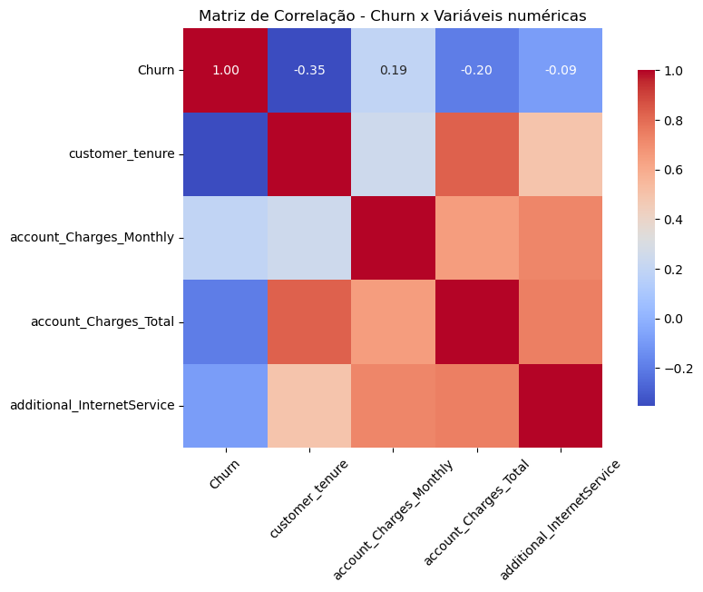

```python
ta.graf_matriz_correlacao(df, colunas_numericas=cols_numericas, titulo='Matriz de Correlação - Churn x Variáveis numéricas').show()
```

#### Segmentação quanto a características do cliente ou da família

```python
ta.calcular_percentual_churn_categoria(df, 'customer_gender')
```

|  | customer_gender | customer | perc_total_customer | churn | perc_churn_customer |
| --- | --- | --- | --- | --- | --- |
| 0 | Female | 3488 | 49.52 | 939 | 26.92 |
| 1 | Male | 3555 | 50.48 | 930 | 26.16 |
| 2 | Total | 7043 | 100.00 | 1869 | 26.54 |

```python
ta.calcular_percentual_churn_categoria(df, 'customer_SeniorCitizen')
```

|  | customer_SeniorCitizen | customer | perc_total_customer | churn | perc_churn_customer |
| --- | --- | --- | --- | --- | --- |
| 0 | 0 | 5901 | 83.79 | 1393 | 23.61 |
| 1 | 1 | 1142 | 16.21 | 476 | 41.68 |
| 2 | Total | 7043 | 100.00 | 1869 | 26.54 |

```python
ta.calcular_percentual_churn_categoria(df, 'customer_Partner')
```

|  | customer_Partner | customer | perc_total_customer | churn | perc_churn_customer |
| --- | --- | --- | --- | --- | --- |
| 0 | 0 | 3641 | 51.7 | 1200 | 32.96 |
| 1 | 1 | 3402 | 48.3 | 669 | 19.66 |
| 2 | Total | 7043 | 100.0 | 1869 | 26.54 |

```python
ta.calcular_percentual_churn_categoria(df, 'customer_Dependents')
```

|  | customer_Dependents | customer | perc_total_customer | churn | perc_churn_customer |
| --- | --- | --- | --- | --- | --- |
| 0 | 0 | 4933 | 70.04 | 1543 | 31.28 |
| 1 | 1 | 2110 | 29.96 | 326 | 15.45 |
| 2 | Total | 7043 | 100.00 | 1869 | 26.54 |

#### Segmentação quanto ao custo com seviços

```python
ta.calcular_percentual_churn_categoria(df, 'account_Charges_Monthly_bins')
```

|  | account_Charges_Monthly_bins | customer | perc_total_customer | churn | perc_churn_customer |
| --- | --- | --- | --- | --- | --- |
| 0 | R\$001-R\$020 | 1159 | 16.46 | 101 | 8.71 |
| 1 | R\$021-R\$040 | 719 | 10.21 | 123 | 17.11 |
| 2 | R\$041-R\$060 | 1100 | 15.62 | 275 | 25.00 |
| 3 | R\$061-R\$080 | 1553 | 22.05 | 521 | 33.55 |
| 4 | R\$081-R\$100 | 1721 | 24.44 | 638 | 37.07 |
| 5 | R\$101-R\$120 | 791 | 11.23 | 211 | 26.68 |
| 6 | Total | 7043 | 100.00 | 1869 | 26.54 |

#### Segmentação quanto ao tempo/ tipo de contrato

```python
ta.calcular_percentual_churn_categoria(df, 'customer_tenure_bins')
```

|  | customer_tenure_bins | customer | perc_total_customer | churn | perc_churn_customer |
| --- | --- | --- | --- | --- | --- |
| 0 | 001-012 | 2186 | 31.04 | 1037 | 47.44 |
| 1 | 013-024 | 1024 | 14.54 | 294 | 28.71 |
| 2 | 025-036 | 832 | 11.81 | 180 | 21.63 |
| 3 | 037-048 | 762 | 10.82 | 145 | 19.03 |
| 4 | 049-060 | 832 | 11.81 | 120 | 14.42 |
| 5 | 061-072 | 1407 | 19.98 | 93 | 6.61 |
| 6 | Total | 7043 | 100.00 | 1869 | 26.54 |

```python
ta.calcular_percentual_churn_categoria(df[df.customer_tenure_bins == '001-012'], 'customer_tenure')
```

|  | customer_tenure | customer | perc_total_customer | churn | perc_churn_customer |
| --- | --- | --- | --- | --- | --- |
| 0 | 1 | 624 | 28.55 | 380 | 60.90 |
| 1 | 2 | 238 | 10.89 | 123 | 51.68 |
| 2 | 3 | 200 | 9.15 | 94 | 47.00 |
| 3 | 4 | 176 | 8.05 | 83 | 47.16 |
| 4 | 5 | 133 | 6.08 | 64 | 48.12 |
| 5 | 6 | 110 | 5.03 | 40 | 36.36 |
| 6 | 7 | 131 | 5.99 | 51 | 38.93 |
| 7 | 8 | 123 | 5.63 | 42 | 34.15 |
| 8 | 9 | 119 | 5.44 | 46 | 38.66 |
| 9 | 10 | 116 | 5.31 | 45 | 38.79 |
| 10 | 11 | 99 | 4.53 | 31 | 31.31 |
| 11 | 12 | 117 | 5.35 | 38 | 32.48 |
| 12 | Total | 2186 | 100.00 | 1037 | 47.44 |

```python
ta.calcular_percentual_churn_categoria(df, 'account_Contract_Monthly')
```

|  | account_Contract_Monthly | customer | perc_total_customer | churn | perc_churn_customer |
| --- | --- | --- | --- | --- | --- |
| 0 | 0 | 3168 | 44.98 | 214 | 6.76 |
| 1 | 1 | 3875 | 55.02 | 1655 | 42.71 |
| 2 | Total | 7043 | 100.00 | 1869 | 26.54 |

```python
ta.calcular_percentual_churn_categoria(df, 'account_Contract')
```

|  | account_Contract | customer | perc_total_customer | churn | perc_churn_customer |
| --- | --- | --- | --- | --- | --- |
| 0 | Month-to-month | 3875 | 55.02 | 1655 | 42.71 |
| 1 | One year | 1473 | 20.91 | 166 | 11.27 |
| 2 | Two year | 1695 | 24.07 | 48 | 2.83 |
| 3 | Total | 7043 | 100.00 | 1869 | 26.54 |

#### Segmentação quanto ao tipo de serviços

```python
ta.calcular_percentual_churn_categoria(df, 'only_PhoneService')
```

|  | only_PhoneService | customer | perc_total_customer | churn | perc_churn_customer |
| --- | --- | --- | --- | --- | --- |
| 0 | 0 | 5517 | 78.33 | 1756 | 31.83 |
| 1 | 1 | 1526 | 21.67 | 113 | 7.40 |
| 2 | Total | 7043 | 100.00 | 1869 | 26.54 |

```python
ta.calcular_percentual_churn_categoria(df, 'only_InternetService')
```

|  | only_InternetService | customer | perc_total_customer | churn | perc_churn_customer |
| --- | --- | --- | --- | --- | --- |
| 0 | 0 | 6361 | 90.32 | 1699 | 26.71 |
| 1 | 1 | 682 | 9.68 | 170 | 24.93 |
| 2 | Total | 7043 | 100.00 | 1869 | 26.54 |

```python
ta.calcular_percentual_churn_categoria(df, 'both_Phone_InternetService')
```

|  | both_Phone_InternetService | customer | perc_total_customer | churn | perc_churn_customer |
| --- | --- | --- | --- | --- | --- |
| 0 | 0 | 2208 | 31.35 | 283 | 12.82 |
| 1 | 1 | 4835 | 68.65 | 1586 | 32.80 |
| 2 | Total | 7043 | 100.00 | 1869 | 26.54 |

#### Segmentação quanto a clientes com serviços de telefone

```python
ta.calcular_percentual_churn_categoria(df, 'phone_PhoneService')
```

|  | phone_PhoneService | customer | perc_total_customer | churn | perc_churn_customer |
| --- | --- | --- | --- | --- | --- |
| 0 | 0 | 682 | 9.68 | 170 | 24.93 |
| 1 | 1 | 6361 | 90.32 | 1699 | 26.71 |
| 2 | Total | 7043 | 100.00 | 1869 | 26.54 |

```python
ta.calcular_percentual_churn_categoria(df, 'phone_MultipleLines')
```

|  | phone_MultipleLines | customer | perc_total_customer | churn | perc_churn_customer |
| --- | --- | --- | --- | --- | --- |
| 0 | 0 | 4072 | 57.82 | 1019 | 25.02 |
| 1 | 1 | 2971 | 42.18 | 850 | 28.61 |
| 2 | Total | 7043 | 100.00 | 1869 | 26.54 |

```python
ta.calcular_percentual_churn_categoria(df[df.phone_PhoneService == 1], 'phone_MultipleLines')
```

|  | phone_MultipleLines | customer | perc_total_customer | churn | perc_churn_customer |
| --- | --- | --- | --- | --- | --- |
| 0 | 0 | 3390 | 53.29 | 849 | 25.04 |
| 1 | 1 | 2971 | 46.71 | 850 | 28.61 |
| 2 | Total | 6361 | 100.00 | 1699 | 26.71 |

#### Segmentação quanto a clientes com serviços de internet

```python
ta.calcular_percentual_churn_categoria(df, 'internet_InternetService')
```

|  | internet_InternetService | customer | perc_total_customer | churn | perc_churn_customer |
| --- | --- | --- | --- | --- | --- |
| 0 | 0 | 1526 | 21.67 | 113 | 7.40 |
| 1 | 1 | 5517 | 78.33 | 1756 | 31.83 |
| 2 | Total | 7043 | 100.00 | 1869 | 26.54 |

```python
ta.calcular_percentual_churn_categoria(df, 'internet_Service_Description')
```

|  | internet_Service_Description | customer | perc_total_customer | churn | perc_churn_customer |
| --- | --- | --- | --- | --- | --- |
| 0 | DSL | 2421 | 34.37 | 459 | 18.96 |
| 1 | Fiber optic | 3096 | 43.96 | 1297 | 41.89 |
| 2 | No | 1526 | 21.67 | 113 | 7.40 |
| 3 | Total | 7043 | 100.00 | 1869 | 26.54 |

```python
ta.calcular_percentual_churn_categoria(df, 'additional_InternetService')
```

|  | additional_InternetService | customer | perc_total_customer | churn | perc_churn_customer |
| --- | --- | --- | --- | --- | --- |
| 0 | 0 | 2219 | 31.51 | 475 | 21.41 |
| 1 | 1 | 966 | 13.72 | 442 | 45.76 |
| 2 | 2 | 1033 | 14.67 | 370 | 35.82 |
| 3 | 3 | 1118 | 15.87 | 306 | 27.37 |
| 4 | 4 | 852 | 12.10 | 190 | 22.30 |
| 5 | 5 | 571 | 8.11 | 71 | 12.43 |
| 6 | 6 | 284 | 4.03 | 15 | 5.28 |
| 7 | Total | 7043 | 100.00 | 1869 | 26.54 |

```python
ta.calcular_percentual_churn_categoria(df[df.internet_InternetService == 1], 'additional_InternetService')
```

|  | additional_InternetService | customer | perc_total_customer | churn | perc_churn_customer |
| --- | --- | --- | --- | --- | --- |
| 0 | 0 | 693 | 12.56 | 362 | 52.24 |
| 1 | 1 | 966 | 17.51 | 442 | 45.76 |
| 2 | 2 | 1033 | 18.72 | 370 | 35.82 |
| 3 | 3 | 1118 | 20.26 | 306 | 27.37 |
| 4 | 4 | 852 | 15.44 | 190 | 22.30 |
| 5 | 5 | 571 | 10.35 | 71 | 12.43 |
| 6 | 6 | 284 | 5.15 | 15 | 5.28 |
| 7 | Total | 5517 | 100.00 | 1756 | 31.83 |

#### Segmentação quanto a forma/ informações de pagamento

```python
ta.calcular_percentual_churn_categoria(df, 'account_PaperlessBilling')
```

|  | account_PaperlessBilling | customer | perc_total_customer | churn | perc_churn_customer |
| --- | --- | --- | --- | --- | --- |
| 0 | 0 | 2872 | 40.78 | 469 | 16.33 |
| 1 | 1 | 4171 | 59.22 | 1400 | 33.57 |
| 2 | Total | 7043 | 100.00 | 1869 | 26.54 |

```python
ta.calcular_percentual_churn_categoria(df, 'account_PaymentMethod')
```

|  | account_PaymentMethod | customer | perc_total_customer | churn | perc_churn_customer |
| --- | --- | --- | --- | --- | --- |
| 0 | Bank transfer (automatic) | 1544 | 21.92 | 258 | 16.71 |
| 1 | Credit card (automatic) | 1522 | 21.61 | 232 | 15.24 |
| 2 | Electronic check | 2365 | 33.58 | 1071 | 45.29 |
| 3 | Mailed check | 1612 | 22.89 | 308 | 19.11 |
| 4 | Total | 7043 | 100.00 | 1869 | 26.54 |

### Salvar relatório de análise de dados após tratamento

```python
# lt.save_profile_report(df, "./report/telecom_data_report_after", title="Relatório de Análise de Dados da Telecom X - Depois do tratamento de dados")
```

```python
# df[['customerID', 'account_Charges_Monthly', 'account_Charges_Total', 'customer_tenure']].to_csv('./test/numerical.csv', index=False)
```

## Introdução:

#### Na base temos dados sobre:

- Evasão de clientes
- Características dos clientes, como faixa etária, e composição da família
- Tempos e tipos de contratos
- Informações sobre serviços de telefonia
- Informações sobre serviços de internet
- Informações sobre cobrança, como tipo de fatura, métodos de pagamentos e custos com serviços

#### Com esses dados é possível gerar informações consolidados, análises estatísticas e visualizações gráficas para apoiar o objetivo de analisar o problema de evasão de clientes

## Limpeza e Tratamento de Dados:

Para as tarefas de tratamento de limpeza de dados, foram executadas as seguintes ações:

- Os dados foram importados de uma base de dados em formato JSON;
- Foram realizadas tarefas de normalização dos dados, utilizando as colunas 'customerID' e 'Churn' como metadados e expandindo as colunas 'customer', 'phone', 'internet' e 'account';
- Foram identificados as variáveis categóricas e as variáveis de valores numéricas;
- Foi identificado que na variável Churn haviam 224 registros (3,08% do total) inválidos e foram deletados da base de dados de análise;
- Foram identificados 11 registros sem valores na váriavel 'account_Charges_Total' e com valor '0' na variável 'customer_tenure'. para cada registros foi atribuído o valor da variável account_Charges_Monthly;
- Foram identificados 11 registros com valor '0' na variável customer_tenure e foi atribuído o valor '1';
- Todas as colunas categóricas com valores de domínio 'yes' e 'no' foram transformadas para valores binários respectivamente '1' e '0';
- Conversão da variável 'account_Charges_Total' para tipo float;
- Foram criadas variáveis:
  - Cria variável discritiva com serviço de internet contratado ('internet_Service_Description');
  - Converte váriavel discritiva de serviço de internet em variável binária que verifica se cliente assina serviço de internet independente se é 'DSL' ou 'Fiber optic' ('internet_InternetService');
  - Váriavel categórica de meses de contrato, agrupado por 12 meses ('customer_tenure_bins');
  - Váriavel categórica de custo mensal, agrupado por R$20,00 ('account_Charges_Monthly_bins');
  - Váriavel binária se o contrato é mensal ou não ('account_Contract_Monthly');
  - Váriavel com total de serviços adicionais de internet contratado ('additional_InternetService');
  - Váriavel binária com informações de clientes somente com serviço de telefonia ('only_PhoneService');
  - Váriavel binária com informações de clientes somente com serviço de internet ('only_InternetService');
  - Váriavel binária com informações de clientes com ambos serviços de telefonia e internet ('both_Phone_InternetService');
  - Váriavel numérica com gaastos diários de clientes considerando mês comercial de 30 dias ('account_Charges_Daily');

## Análise Exploratória de Dados:

Apresente as análises feitas, incluindo gráficos e visualizações para identificar padrões.

```python
%matplotlib inline
```

### Foi possível identificar uma taxa de evasão de clientes de 26,5% da base de clientes analisadas

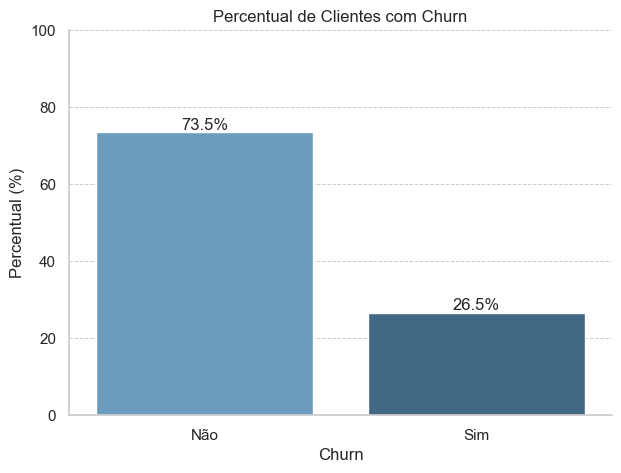

```python
ta.graf_percentual_chrun(df).show()
```

### Analise segmentada da base de clientes

### Segmentação quanto a características do cliente ou da família

#### Foi identificado que embora a base de clientes com 65 anos ou mais seja relativamente pequena 16,21% (1.142), tem uma alta taxa de evasão de 41,68% (476)

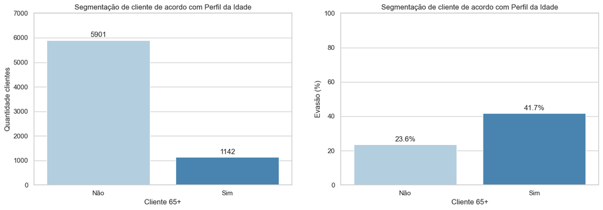

```python
ta.graf_barra_customer_churn(df, var_categorica='customer_SeniorCitizen', titulo='Segmentação de cliente de acordo com Perfil da Idade', x_label='Cliente 65+', y_label1='Quantidade clientes', y_label2='Evasão (%)', converte_bin=True).show()
```

#### Foi identificado que clientes que não tem parceiros e/ou dependentes, tem uma maior taxa de evasão, com 32,96% (1.200) e 31,28% (1.543) respectivamente

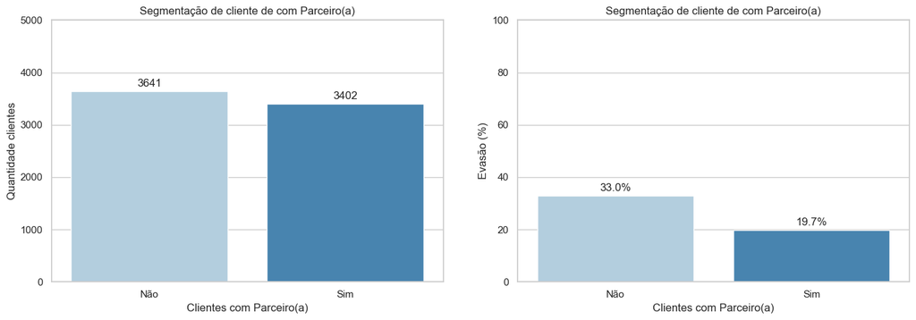

```python
ta.graf_barra_customer_churn(df, var_categorica='customer_Partner', titulo='Segmentação de cliente de com Parceiro(a)', x_label='Clientes com Parceiro(a)', y_label1='Quantidade clientes', y_label2='Evasão (%)', converte_bin=True).show()
```

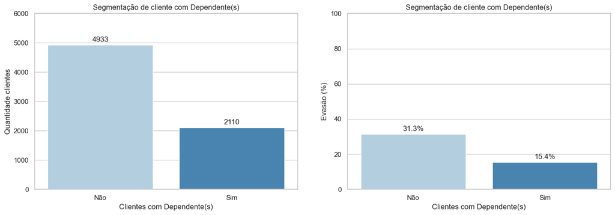

```python
ta.graf_barra_customer_churn(df, var_categorica='customer_Dependents', titulo='Segmentação de cliente com Dependente(s)', x_label='Clientes com Dependente(s)', y_label1='Quantidade clientes', y_label2='Evasão (%)', converte_bin=True).show()
```

### Segmentação quanto ao custo com serviços

#### Analisando o perfil de cliente por agrupamento de custo mensal a cada 20 reais, foi identificado que os clientes com custo entre 81 e 100 reais, representam a maior base de clientes com 24,44% (1.721) e também maior percentual de evasão com 37,07% (638)

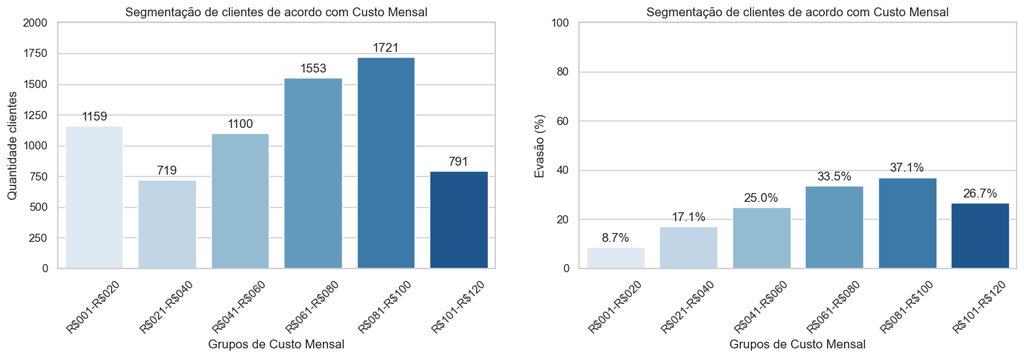

```python
ta.graf_barra_customer_churn(df, var_categorica='account_Charges_Monthly_bins', titulo='Segmentação de clientes de acordo com Custo Mensal', x_label='Grupos de Custo Mensal', y_label1='Quantidade clientes', y_label2='Evasão (%)').show()
```

#### Análise da frequência de Churn por Custo Mensal, indica que aproximadamente 50% dos clientes que cancelaram serviço têm Custo Mensal entre 80 e 120 reais

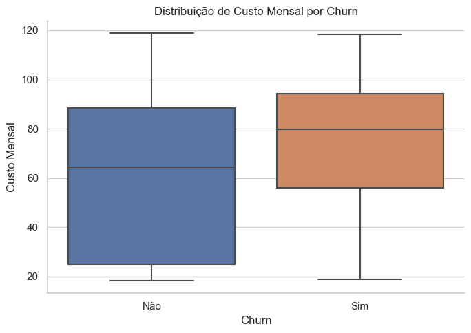

```python
ta.graf_boxplot_churn_varialvel_numerica(df, variavel_numerica='account_Charges_Monthly', titulo='Distribuição de Custo Mensal por Churn', x_label='Churn', y_label='Custo Mensal').show()
```

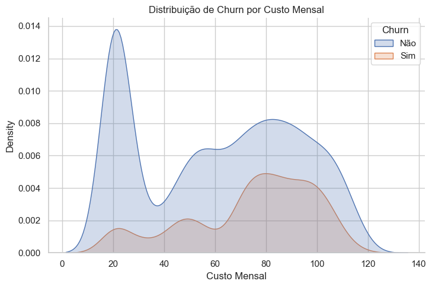

```python
ta.graf_distribuicao_churn_varialvel_numerica(df, variavel_numerica='account_Charges_Monthly', titulo='Distribuição de Churn por Custo Mensal', x_label='Custo Mensal', y_label='').show()
```

### Segmentação quanto ao tempo/ tipo de contrato

#### Foi identificado que os clientes com tempo de contrato igual ou inferior a 12 meses, representam a maior base de clientes com 31,04% (2.186). Dessa base foi identificado o maior percentual de evasão de 47,44% (1.037);

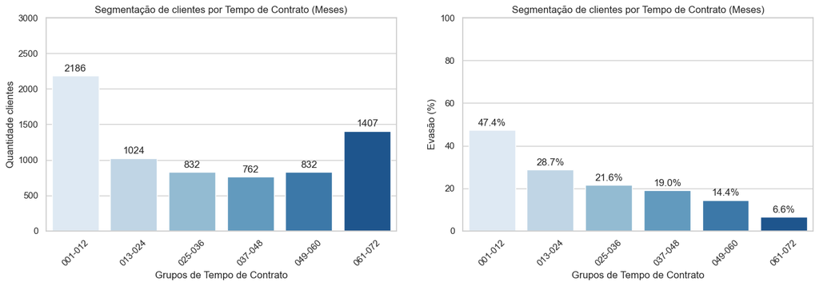

```python
ta.graf_barra_customer_churn(df, var_categorica='customer_tenure_bins', titulo='Segmentação de clientes por Tempo de Contrato (Meses)', x_label='Grupos de Tempo de Contrato', y_label1='Quantidade clientes', y_label2='Evasão (%)').show()
```

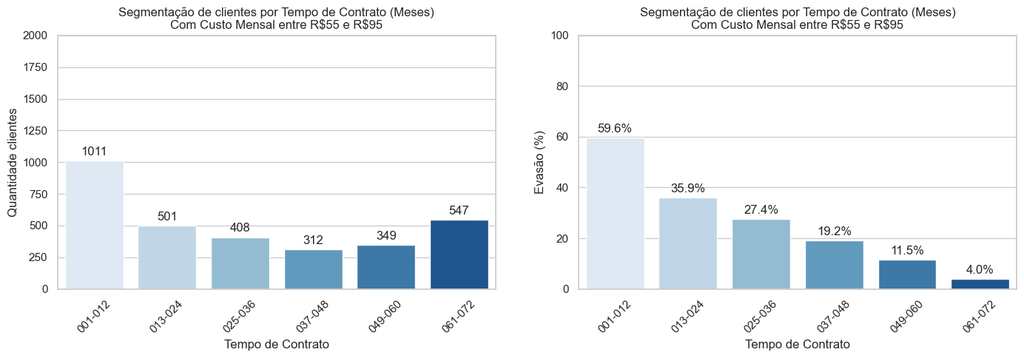

```python
query = "account_Charges_Monthly.between(55, 95)"
ta.graf_barra_customer_churn(df.query(query), var_categorica='customer_tenure_bins', titulo='Segmentação de clientes por Tempo de Contrato (Meses)\nCom Custo Mensal entre R\$55 e R\$95', x_label='Tempo de Contrato', y_label1='Quantidade clientes', y_label2='Evasão (%)').show()
```

#### Evasão de clientes com contrartos entre 1 e 12 meses

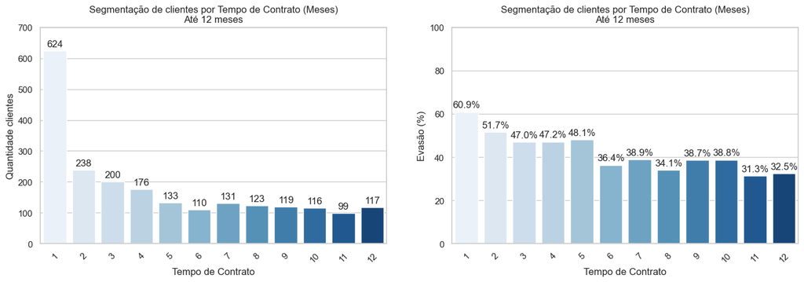

```python
filtro = (df.customer_tenure_bins == '001-012')
ta.graf_barra_customer_churn(df[filtro], var_categorica='customer_tenure', titulo='Segmentação de clientes por Tempo de Contrato (Meses)\nAté 12 meses', x_label='Tempo de Contrato', y_label1='Quantidade clientes', y_label2='Evasão (%)').show()
```

#### Evasão de clientes com contrartos entre 1 e 12 meses e Custo Mensal entre 61 e 100 reais

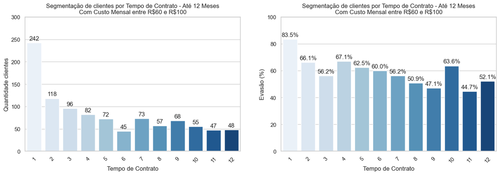

```python
filtro = (df.customer_tenure_bins == '001-012') & (df.account_Charges_Monthly_bins.isin([r'R\$061-R\$080', r'R\$081-R\$100']))
ta.graf_barra_customer_churn(df[filtro], var_categorica='customer_tenure', titulo='Segmentação de clientes por Tempo de Contrato - Até 12 Meses\nCom Custo Mensal entre R\$60 e R\$100', x_label='Tempo de Contrato', y_label1='Quantidade clientes', y_label2='Evasão (%)').show()
```

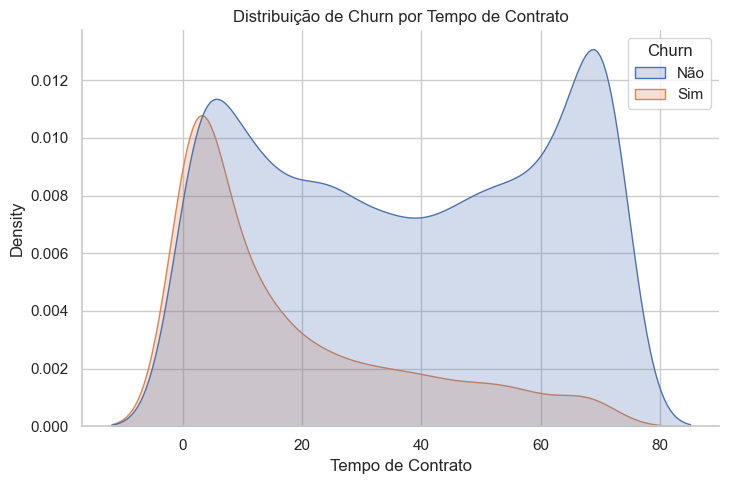

```python
ta.graf_distribuicao_churn_varialvel_numerica(df, variavel_numerica='customer_tenure', titulo='Distribuição de Churn por Tempo de Contrato', x_label='Tempo de Contrato', y_label='').show()
```

#### A Relação de evasão entre clientes que possuem pouco tempo de contrato, mas, com Custo Mensal alto (entre 80 e 100 reais), resulta em evsão com clientes com Valor Total baixo (inicio da distribuição)

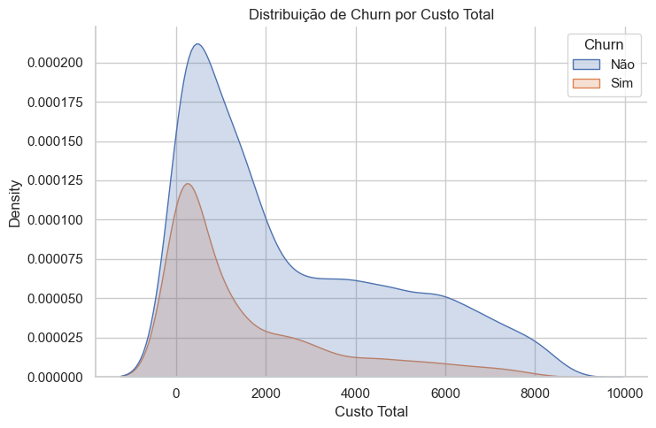

```python
ta.graf_distribuicao_churn_varialvel_numerica(df, variavel_numerica='account_Charges_Total', titulo='Distribuição de Churn por Custo Total', x_label='Custo Total', y_label='').show()
```

#### Clientes com contratos mensais representam 55,02% (3.875) da base de clientes e tem uma evasão de 42,71% (1.655)

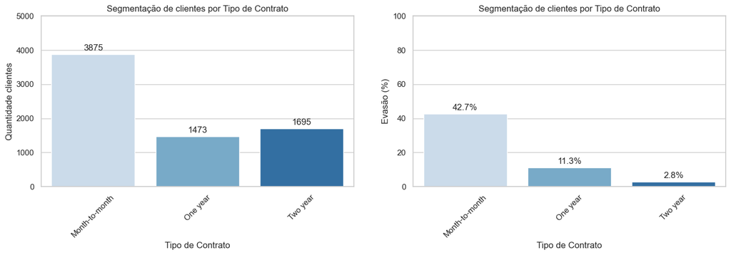

```python
ta.graf_barra_customer_churn(df, var_categorica='account_Contract', titulo='Segmentação de clientes por Tipo de Contrato', x_label='Tipo de Contrato', y_label1='Quantidade clientes', y_label2='Evasão (%)').show()
```

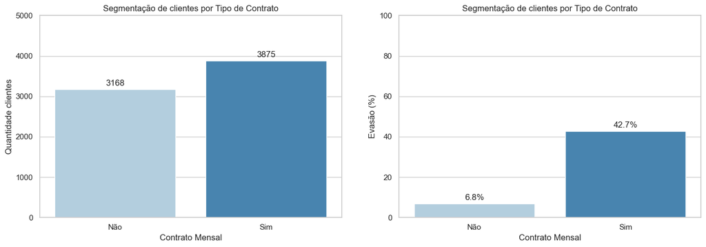

```python
ta.graf_barra_customer_churn(df, var_categorica='account_Contract_Monthly', titulo='Segmentação de clientes por Tipo de Contrato', x_label='Contrato Mensal', y_label1='Quantidade clientes', y_label2='Evasão (%)', converte_bin=True).show()
```

### Segmentação quanto ao tipo de serviços

#### Foi identificado que clientes que assinam somente serviço de telefonia 21,67% (1.526), tem menor taxa de evasão do que a média geral e do que clientes que assinam somente serviços de internet 9,68% (682) com evasão de 24,93% (170)

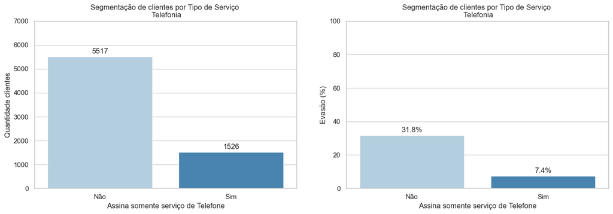

```python
ta.graf_barra_customer_churn(df, var_categorica='only_PhoneService', titulo='Segmentação de clientes por Tipo de Serviço \n Telefonia', x_label='Assina somente serviço de Telefone', y_label1='Quantidade clientes', y_label2='Evasão (%)', converte_bin=True).show()
```

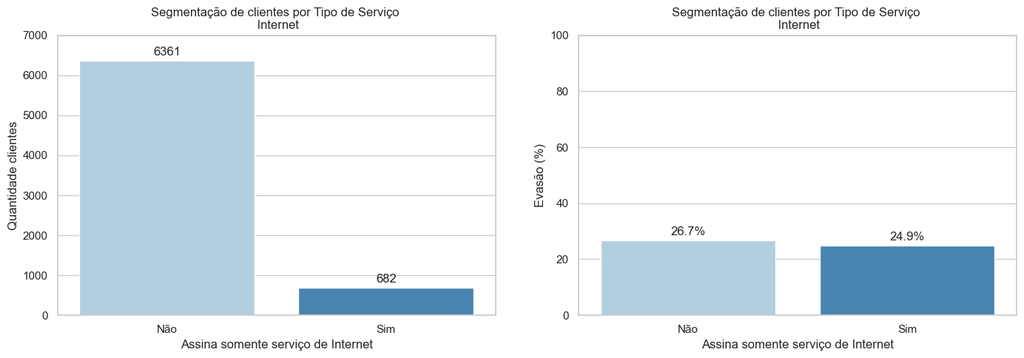

```python
ta.graf_barra_customer_churn(df, var_categorica='only_InternetService', titulo='Segmentação de clientes por Tipo de Serviço \n Internet', x_label='Assina somente serviço de Internet', y_label1='Quantidade clientes', y_label2='Evasão (%)', converte_bin=True).show()
```

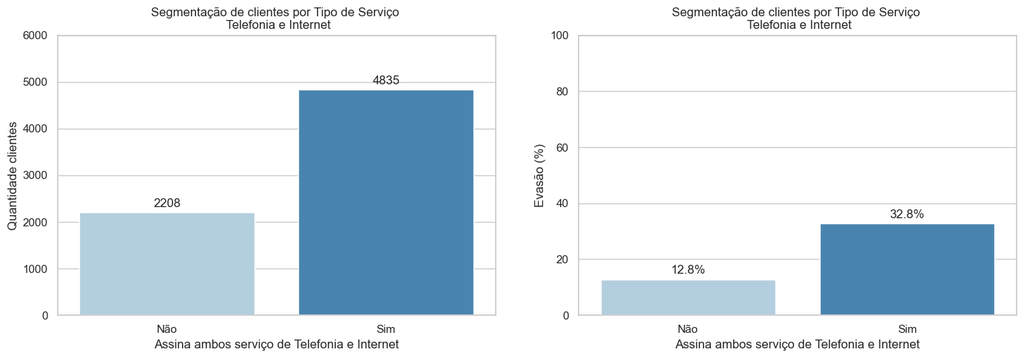

```python
ta.graf_barra_customer_churn(df, var_categorica='both_Phone_InternetService', titulo='Segmentação de clientes por Tipo de Serviço \n Telefonia e Internet', x_label='Assina ambos serviço de Telefonia e Internet', y_label1='Quantidade clientes', y_label2='Evasão (%)', converte_bin=True).show()
```

### Segmentação quanto a serviços de telefone

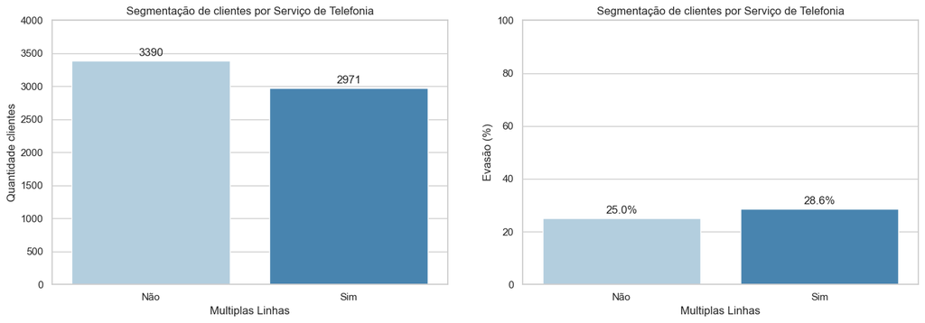

```python
ta.graf_barra_customer_churn(df[df.phone_PhoneService == 1], var_categorica='phone_MultipleLines', titulo='Segmentação de clientes por Serviço de Telefonia', x_label='Multiplas Linhas', y_label1='Quantidade clientes', y_label2='Evasão (%)', converte_bin=True).show()
```

### Segmentação quanto a serviços de internet

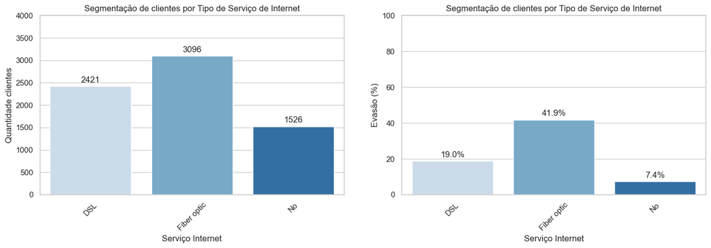

```python
ta.graf_barra_customer_churn(df, var_categorica='internet_Service_Description', titulo='Segmentação de clientes por Tipo de Serviço de Internet', x_label='Serviço Internet', y_label1='Quantidade clientes', y_label2='Evasão (%)').show()
```

#### Clientes com serviços adicionais de internet tendem a ter maior fidelidade de quando têm mais serviços contratados. Identifica-se uma queda progressiva no percentual de evasão conforme ausenta-se a quantidade de serviços contratados

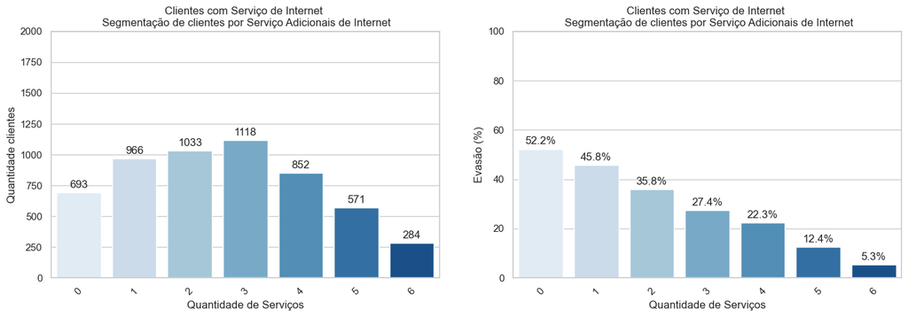

```python
ta.graf_barra_customer_churn(df[df.internet_InternetService == 1], var_categorica='additional_InternetService', titulo='Clientes com Serviço de Internet \n Segmentação de clientes por Serviço Adicionais de Internet', x_label='Quantidade de Serviços', y_label1='Quantidade clientes', y_label2='Evasão (%)').show()
```

### Segmentação quanto a forma/ informações de pagamento

#### Foi identicado que 59,22% (4.171) dos clientes preferem receber a fatura de forma online. Esse perfil de cliente tem uma evasão de 33,57% (1.400) mais que o dobro do que os clientes que recebem fatura impressa 16,33% (469)

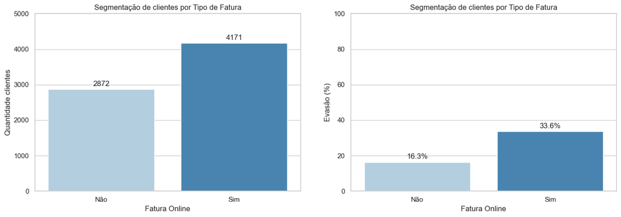

```python
ta.graf_barra_customer_churn(df, var_categorica='account_PaperlessBilling', titulo='Segmentação de clientes por Tipo de Fatura', x_label='Fatura Online', y_label1='Quantidade clientes', y_label2='Evasão (%)', converte_bin=True).show()
```

#### Entre as formas de pagamento, o Electronic check tem a maior representação de clientes com 33,58% (2.365) e também o maior percentual de evasão 45,29% (1.071)

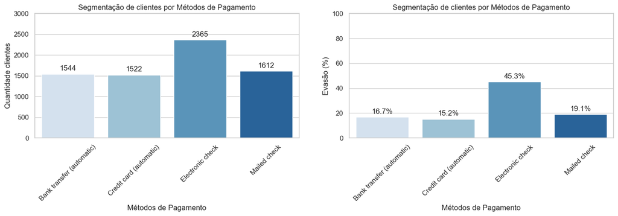

```python
ta.graf_barra_customer_churn(df, var_categorica='account_PaymentMethod', titulo='Segmentação de clientes por Métodos de Pagamento', x_label='Métodos de Pagamento', y_label1='Quantidade clientes', y_label2='Evasão (%)', converte_bin=False).show()
```

### Análise de Variáveis Numéricas

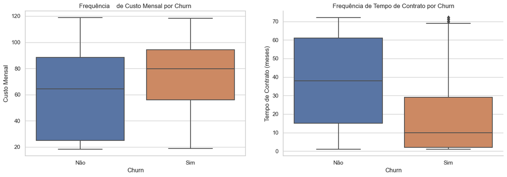

```python
ta.graf_boxplot_churn(df).show()
```

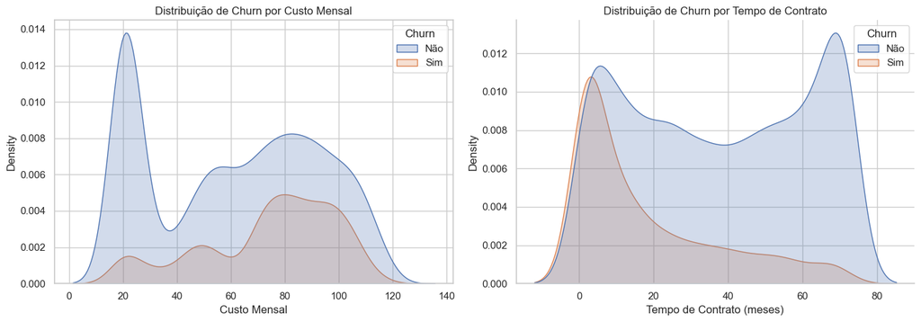

```python
ta.graf_distribuicao_churn(df).show()
```

## Conclusões e Insights:

#### Os principais segmentos de clientes com Churn são os que tem pouco Tempo de Contrato, entre 1 e 12 meses e com Custos Mensais entre 61 e 100 reais

- Isso pode indicar uma base de clientes que são mais sensíveis aos preços dos serviços do que a diversidade ou qualidade dos serviços
- Outra caracteristíca são as altas taxas de evasão de clientes com contratos mensais que reforça a sensibilidade ao preço com pouco apelo de fidelidade de marca
- E também clientes que não tem Companheiro(a) e/ou Dependente(s) têm uma taxa de evasão acima da média geral

#### Outros perfis analisados podem indicar problemas com pós vendas que podem estar relacionado à:

- Alta taxa de evasão de clientes com serviço de Internet com Fibra ótica
- Também temos um percentual de evasão acima da média geral para os clientes com Fatura Online
- Clientes com forma de pagamento em Electronic check
- E clientes +65 anos com alta taxa de evasão que podem sinalizar com a dificuldade de suporte no pós venda
- Clientes que assinam somente serviço de Telefonia tem menor taxa de evasão que clientes que assinam somente serviço de internet ou ambos os serviços

#### Clientes com serviços Adicionais de Internet tendem a ter maior fidelidade:

- De forma inversamente propocional, quando mais serviços Adicionais de Internet o cliente tem contratado, menor é a taxa de evasão

#### Clientes com Multiplas Linhas de telefone tendem a ter uma maior evasão:

- Ao contrário dos serviços Adicionais de Internet, clientes com Múltiplas Linhas de telefone tem taxa de evasão levemente acima da média geral

## Recomendações:

Ofereça sugestões baseadas na sua análise.

#### Para clientes com sensibilidade ao preço possível ações

- Criar planos de contrato com menor tempo, 6 meses, por exemplo
- Criar planos de contrato com menor tempo, como 3, por exemplo, para primeiro contrato
- Criar promoções combinadas com serviços Adicionais de Internet para aumentar a fidelidade do cliente com relação a diversidade de serviços
- Promoção de acesso gratuíto de 10 dias para Streaming de Movies para clientes com Contrato Mensal

#### Para possíveís problemas com pós vendas:

- Criar indicadores de satisfação do cliente relacionados ao pós venda
  - Números de reclamações mensais relacionados com conexão e serviços de Internet
  - Números de reclamações semestrais relacionados com problemas na Fatura
  - Números de reclamações semestrais relacionados a pagamentos com Electronic Check

#### Para ações de fidelidade relacionadas a varidedade de serviços:

- Desconto para clientes com Fatura Online
- Desconto escalonada para clientes com Múltiplas Linhas de telefone
- Programa de pontuação de fidelidade para descontos em renovações de contratos ou aquisição de novos serviços
- Descontos para custo de instalação para contratos com maiores períodos de vigência
- Bônus em descontos para assinatura de serviços adicionais para cientes com índice de reclamação acima de metas estabelecidas